# Assessing Net Color and Color Preferences on Net Use: Rwanda 2017

Hannah Koenker, Tropical Health

24 August, 2023

# Assessing Color Preferences on Net Use: Rwanda 2017

Insecticide-treated nets are the cornerstone of malaria control efforts worldwide. Over 2 billion ITNs have been distributed to people at risk of malaria over the past two decades. While most ITNs are used for malaria prevention, some gaps in use remain. Anecdotal reports and qualitative observations have indicated that in some areas, households may prefer certain colors of ITNs, or that certain ITN colors may have negative connotations.

A 2017 publication reviewed data available at the time on ITN use and net attributes as well as the limited data on color and shape preferences, and found that there was not evidence to support significant increases in net use when households had their preferred shape or color. Since then, additional household surveys have been conducted. This analysis updates the 2017 findings.

# Analysis Approach

## Assess availability and suitability of data for the analysis

1. Download datasets for the most recent MIS or DHS from dhsprogram.com
2. If using an MIS or DHS, the ITN roster data are contained within the household file (files ending with HR). This file must be reshaped to long format, generating a dataset with one row for each net in the household.
3. The outcome variable will be whether the ITN was used the previous night.
4. Many household-level factors influence ITN use, and must be controlled for in the analysis. These variables are nearly always standard within MIS/DHS:
   - region
   - time of year (month of the survey)
   - urban/rural setting
   - socioeconomic status
   - age of the net
   - the number of nets and people within the household - frequently categorized as household owning
     - ‘too few’ ITNs,
     - ‘just right’ number of ITNs, or
     - ‘too many’ ITNs

# Assess the overall proportion of nets of different colors that were used the previous night

Once we have reviewed the availability of the data and the patterns of net use and distribution of colors across different covariates, we are ready to look at how many nets were used the previous night, stratifying by color. This is our overall programmatic indication of differences in net use due to color – although it does not (yet) adjust for covariates. If there is not a big difference in the proportion of nets used the previous night by color, then programmes can be reasonably confident that color won’t have a negative impact on ITN use.

We can see below that 70.6% of white nets were used the previous night, compared to 68% of blue nets, 56.3% of green nets, and 23.3% of nets of other colors. Comparing white to non-white nets, this is a difference of 3.7 percentage points. This is not a programmatically significant difference.

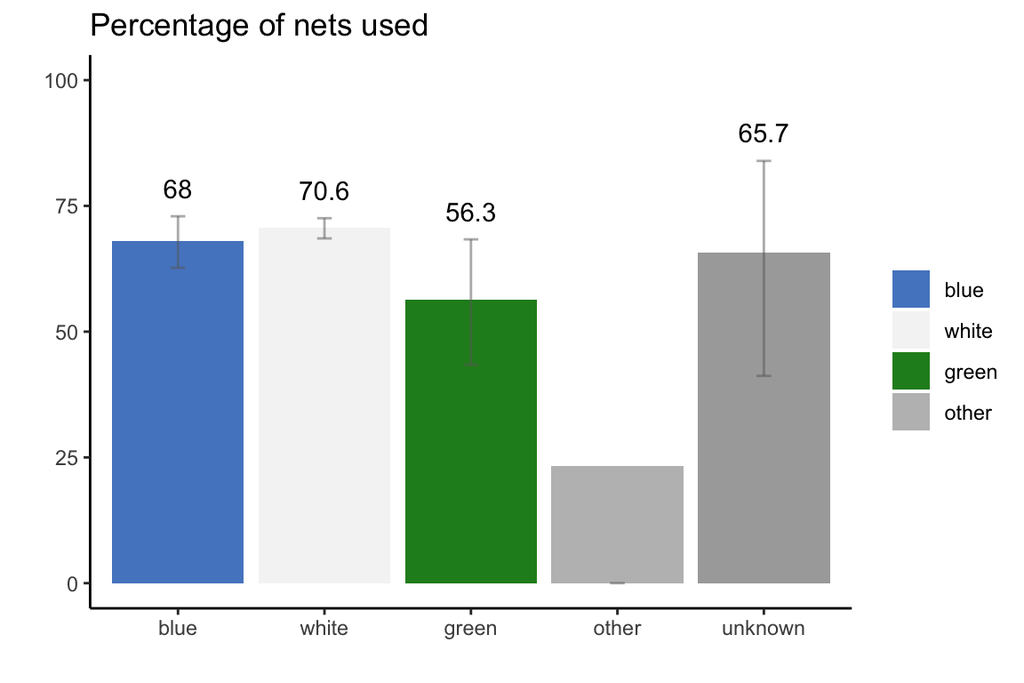

# Assessing the association between net use and color, controlling for co-variates

After reviewing the patterns of net use by color and covariates, we can use generalized linear models to evaluate the associations between covariates and our outcome variable of whether a particular net was used the previous night.

Below is the multivariate model, which controls for background factors typically associated with net use. Is color associated with significant differences in a net being used?

| **Characteristic** | **OR**<sup>1</sup> | **95% CI**<sup>1</sup> | **p-value** |
| --- | --- | --- | --- |
| white | 1.19 | 0.95, 1.48 | 0.13 |
| household net supply |  |  |  |
| not enough | — | — |  |
| just right | 0.75 | 0.62, 0.91 | 0.004 |
| too many | 0.28 | 0.23, 0.35 | <0.001 |
| type of place of residence |  |  |  |
| urban | — | — |  |
| rural | 0.95 | 0.73, 1.23 | 0.7 |
| wealth index combined |  |  |  |
| poorest | — | — |  |
| poorer | 0.98 | 0.81, 1.19 | 0.9 |
| middle | 1.14 | 0.95, 1.37 | 0.2 |
| richer | 1.17 | 0.96, 1.42 | 0.11 |
| richest | 1.36 | 1.08, 1.70 | 0.009 |
| age of net in years |  |  |  |
| <1 year | — | — |  |
| 1-2 years | 0.97 | 0.82, 1.16 | 0.7 |
| 2-3 years | 0.96 | 0.75, 1.23 | 0.8 |
| 3+ years | 0.51 | 0.41, 0.64 | <0.001 |

*Results control for region (not shown)*  
<sup>1</sup> OR = Odds Ratio, CI = Confidence Interval

What do you notice about the multivariate model results? Which covariates are significantly associated, and which ones have the largest reductions or increases in odds ratio? Is the net color significantly associated with the net having been used the previous night?

In the above model, we see that the odds of a white ITN being used the previous night are 1.186, versus the odds of a non-white net being used, with a p-value of 0.126.

# Is color associated with differences in net use?

> Given the results above, there is no evidence to suggest that the color of the net makes a substantial difference in overall net use.

# Canevas d’analyse pour evaluer l’association entre des preferences du tissu et l’’utilisation des moustiquaires impregnées d’insecticide: Rwanda 2017

Les moustiquaires imprégnées d’insecticide sont le premier outil des efforts de lutte contre le paludisme dans le monde. Plus de 2 milliards de MII ont été distribuées aux personnes à risque de paludisme au cours des deux dernières décennies. Alors que la plupart des MII sont utilisées pour la prévention du paludisme, certaines lacunes subsistent dans leur utilisation. Des rapports anecdotiques et des observations qualitatives ont indiqué que dans certaines endroits, les ménages peuvent préférer les MII en certain couleurs, car d’autres couleurs ont des connotations negatives.

En conséquence, les programmes nationaux de lutte contre le paludisme ont exprimé le souhait de se procurer des MII des couleurs spécifiques pour les prochaines campagnes de distribution de masse. Il y a quelques années, PMI a limité la couleur des MII à blanche seulement, afin de reduire les couts associés avec beaucoup d’options. Bien que le système d’approvisionnement du Fonds mondial autorise plusieurs couleurs, il est en train de considerer une reduction similaire dans les options pour les MII, pour reduire les couts et permettre les programmes d’acheter plus de MII pour leurs populations.

Un article publié en 2017 a resumé les données disponibles à l’époch sur l’utilisation des MII et les characteristiques des moustiquaires, telles que la couleur et la forme, et n’a pas trouvé des associations significatives entre ces variables et l’utilisation. Dès lors, de nouveax enquetes ont été menés. Cette analyse mets à jour celle du 2017.

# Approche d’analyse

## Évaluer la disponibilité et la pertinence des données pour l’analyse

1. Téléchargez les ensembles de données pour le MIS ou le DHS ou le MICS le plus récent sur dhsprogram.com ou mics.unicef.org
2. Si vous utilisez un MIS ou une EDS, les données de la liste des MII sont contenues dans le fichier des ménages (fichiers se terminant par HR). Ce fichier doit être remodelé au format long, générant un ensemble de données avec une ligne pour chaque moustiquaire dans le ménage. Les ensembles de données MICS ont un fichier MII (TN) distinct.
3. La variable de résultat sera de savoir si la MII a été utilisée la nuit précédente.
4. De nombreux facteurs au niveau des ménages influencent l’utilisation des MII et doivent être pris en compte dans l’analyse. Ces variables sont presque toujours standard dans les MIS/DHS/MICS:
   - Région
   - Période de l’année (mois de l’enquête)
   - Milieu urbain/rural
   - Statut socioéconomique
   - Age de la MII
   - Le nombre de moustiquaires et de personnes au sein du ménage - fréquemment classées comme propriétaires du ménage
     - «trop peu» de MII,
     - le nombre «juste» de MII, ou
     - «trop» de MII

# Évaluer la proportion globale de moustiquaires de différents couleurs qui ont été utilisées la nuit précédente

Une fois que nous avons examiné la disponibilité des données et les motifs d’utilisation des moustiquaires et de distribution des couleurs à travers différentes covariables, nous sommes prêts à examiner le nombre de moustiquaires utilisées la nuit précédente, en stratifiant par couleur. Ceci est notre indication programmatique des différences d’utilisation des moustiquaires dues au couleur - bien qu’elle ne s’ajuste pas (encore) aux covariables. S’il n’y a pas une grande différence dans la proportion de moustiquaires utilisées la nuit précédente par couleur, il est peu probable que les défis logistiques (y compris les retards potentiels) liés à l’achat d’un seul couleur valent la peine.

Nous pouvons voir ci-dessous que 70.6 pour cent des moustiquaires blanches ont été utilisés la nuit précédente, par rapport à 68 pour cent des moustiquaires bleues, 56.3 pour cent des moustiquaires vertes, et 23.3 pour cent des moustiquaires d’autres couleurs. Si l’on compare des moustiquaires blanches contre les autres couleurs, c’est une difference de 3.7 points de pourcentage. Ce difference n’est pas une différence significative du point de vue du programme.

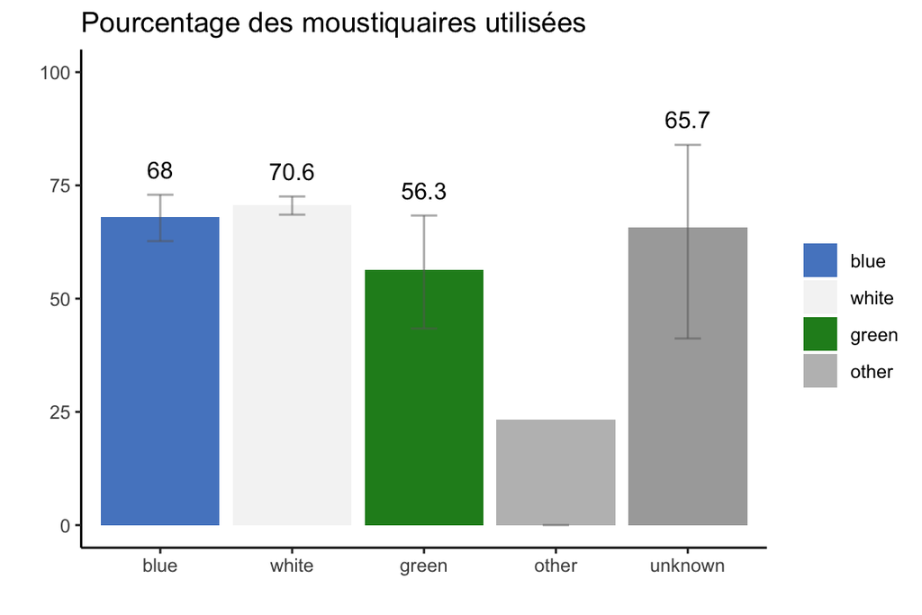

# Évaluer l’association entre l’utilisation de la moustiquaire et son couleur, en contrôlant les covariables

Après avoir examiné les modèles d’utilisation des moustiquaires par la couleur et les covariables, nous pouvons utiliser des modèles linéaires généralisés pour évaluer les associations entre les covariables et notre variable de résultat pour savoir si une moustiquaire particulière a été utilisée la nuit précédente.

Nous pouvons construire le modèle multivarié. Lors du contrôle des facteurs contextuels, la couleur est-il associé à des différences significatives dans l’utilisation d’une moustiquaire ?

| **Characteristic** | **OR**<sup>1</sup> | **95% CI**<sup>1</sup> | **p-value** |
| --- | --- | --- | --- |
| white | 1.19 | 0.95, 1.48 | 0.13 |
| household net supply |  |  |  |
| not enough | — | — |  |
| just right | 0.75 | 0.62, 0.91 | 0.004 |
| too many | 0.28 | 0.23, 0.35 | <0.001 |
| type of place of residence |  |  |  |
| urban | — | — |  |
| rural | 0.95 | 0.73, 1.23 | 0.7 |
| wealth index combined |  |  |  |
| poorest | — | — |  |
| poorer | 0.98 | 0.81, 1.19 | 0.9 |
| middle | 1.14 | 0.95, 1.37 | 0.2 |
| richer | 1.17 | 0.96, 1.42 | 0.11 |
| richest | 1.36 | 1.08, 1.70 | 0.009 |
| age of net in years |  |  |  |
| <1 year | — | — |  |
| 1-2 years | 0.97 | 0.82, 1.16 | 0.7 |
| 2-3 years | 0.96 | 0.75, 1.23 | 0.8 |
| 3+ years | 0.51 | 0.41, 0.64 | <0.001 |

*Les resultats controllent pour la region (non-montré)*  
<sup>1</sup> OR = Odds Ratio, CI = Confidence Interval

Que remarquez-vous sur les résultats du modèle multivarié ? Quelles covariables sont significativement associées et lesquelles ont les plus fortes réductions ou augmentations du rapport de cotes ? La couleur de la moustiquaire est-il significativement associé au fait que la moustiquaire a été utilisée la nuit précédente ?

# La couleur est-il associé à des différences d’utilisation des moustiquaires?

> Compte tenu des résultats ci-dessus, il n’y a aucune preuve suggérant que la couleur de la moustiquaire fait une différence substantielle dans l’utilisation globale de la moustiquaire.